# Initial Findings

Compartment Syndrome in Pediatric Patients

Matt Carlson

5/17/2020

```r
pacman::p_load( traumaR,
                tidytable,
                tidymodels,
                tidyverse,
                ggplot2,
                ggthemes,
                rlang,
                forcats,
                tictoc,
                gt,
                vip,
                DMwR,
                rpart,
                themis,    #github version
                rpart.plot,
                ROSE,
                yardstick)

options(scipen=999)  #remove scientific notation
knitr::opts_chunk$set(echo = FALSE, warning = FALSE)
```

# Project Objective

The objective is to identify the likelihood of acute compartment syndrome (CS) in pediatric patients (less than seventeen years old) who suffered from forearm fractures, ultimately resulting in CS. I plan to study those who likely had more severe injuries or who had an unacceptable result from their treatment in the emergency department (ED). The majority of forearm fractures in children are treated with closed reduction and casting, then discharged from the ED.

## What is Compartment Syndrome?

Compartment syndrome (CS) refers to the increased pressure inside the section of the limb that contains muscles, nerves, and blood vessels. This increased pressure results in the reduction of blood supply and tissue necrosis. It usually develops in the lower leg and forearm after traumas like a bone fracture. If not treated in time, it can lead to permanent muscle and nerve damage.

CS typically develops after surgery or trauma, causing excessive fluid in the fascia, causing pressure and pain in the affected limb. The decreased circulation causes the muscle can die, resulting in permanent damage left untreated. Treatment of compartment syndrome is a fasciotomy or removal of external compression, which can relieve the pressure and maintains blood flow to the muscle.

# Data Overview

The primary data comes from the **Pennsylvania Trauma Outcome System** (PTOS), which contains results from 2010 - 2015. There are approximately 530k anonymized patient records and 1,400 columns of descriptive information regarding each procedure. The data requires a significant amount of manipulation to normalize and prepare it for analysis. Furthermore, I will separate the initial PTOS data into normalized data structures focused on demographics, prehospital, medical procedures, and outcomes. The PTOS data uses medical coding to classify causes of injury, examination results, processes, and treatments. I will use the International Statistical Classification of Diseases and Related Health Problems (ICD) data to translate codes into descriptive terms accurately.

## Data Wrangling

I created an R Package, traumaR, and hosted it in a GitHub repo. This allows for repeatable analysis and creates safeguards from any potential mishaps with coding failures. This package stores all of the data wrangling procedures and over **50** custom functions designed to translate the medical codes into human-friendly descriptions.

### Raw Data Structure

The PTOS raw data is structured so that each patient’s information is found on the same row. For example, if a patient has five surgical procedures, those results would be shown across five different columns. This data structure introduced many challenges for identifying patterns in surgical sequencing. Here is a sample of the raw data.

```
## # A tibble: 10 x 1,465
##    id    alias_inst_num trauma_num pat_adr_z e_code e_code_2 e1_icd10 e2_icd10
##    <chr>          <int>      <int>     <int>  <dbl>    <dbl> <chr>    <chr>
##  1 0123~             18   20000011     19373   960        NA <NA>     <NA>
##  2 0208~             15   20000001        NA   815        NA <NA>     <NA>
##  3 0527~             15   20000003     18914   815        NA <NA>     <NA>
##  4 0312~              8    2000018     15025   816        NA <NA>     <NA>
##  5 1104~              8   20000006     16112   815.       NA <NA>     <NA>
##  6 1016~              8   20000017     15601   959.       NA <NA>     <NA>
##  7 0903~             11   20000007     19096   886.       NA <NA>     <NA>
##  8 0401~             11   20000008     19036   815.       NA <NA>     <NA>
##  9 0816~              3   20000001     17313   918.       NA <NA>     <NA>
## 10 0407~              3   20000005     17370   812.       NA <NA>     <NA>
## # ... with 1,457 more variables: hgt_fall <int>, e849_x <int>, pl_icd10 <chr>,
## #   e_act_1 <chr>, act_icd10 <chr>, race <int>, ethnicity <int>, sex <int>,
## #   d_birth_a <chr>, raw_age <int>, age_type <int>, inj_date_a <chr>,
## #   inj_time_a <chr>, county_pa <int>, state_pa <chr>, prot_dev_1 <int>,
## #   prot_dev_2 <int>, prot_dev_3 <int>, inj_type <int>, inj_type2 <int>,
## #   burn_type <int>, pec_1 <chr>, pec_2 <chr>, pec_3 <chr>, pec_4 <chr>,
## #   pec_5 <chr>, pec_6 <chr>, pec_7 <chr>, pec_8 <chr>, pec_9 <chr>,
## #   pec_10 <chr>, pec_s <chr>, extric_s <int>, one_provid <int>,
## #   scene_data <int>, transp_s <int>, pre_s_d_da <chr>, pre_s_d_ta <chr>,
## #   pre_s_a_da <chr>, pre_s_a_ta <chr>, pre_s_l_da <chr>, pre_s_l_ta <chr>,
## #   ems_code_s <int>, ems_unit_s <int>, run_form_s <int>, run_num_s <chr>,
## #   life_ps <int>, life_cs <int>, vitals_s <int>, pulse_s <int>,
## #   resp_rat_s <int>, sys_bp_s <int>, eye_opng_s <int>, ver_resp_s <int>,
## #   mot_resp_s <int>, gcs_calc_s <int>, gcsq_s_01 <lgl>, gcsq_s_02 <lgl>,
## #   gcsq_s_03 <lgl>, par_drg_ys <chr>, intubat_s <int>, assi_onv_s <int>,
## #   vent_rat_s <int>, transp_1 <int>, pre_1_d_da <chr>, pre_1_d_ta <chr>,
## #   pre_1_a_da <chr>, pre_1_a_ta <chr>, pre_1_l_da <chr>, pre_1_l_ta <chr>,
## #   ems_code_1 <int>, ems_unit_1 <int>, run_form_1 <int>, run_num_1 <chr>,
## #   life_p1 <int>, life_c1 <int>, pulse_1 <int>, resp_rat_1 <int>,
## #   sys_bp_1 <int>, eye_opng_1 <int>, ver_resp_1 <int>, mot_resp_1 <int>,
## #   gcs_calc_1 <int>, gcsq_1_01 <lgl>, gcsq_1_02 <lgl>, gcsq_1_03 <lgl>,
## #   par_drg_y1 <chr>, intubat_1 <int>, assi_onv_1 <int>, vent_rat_1 <int>,
## #   transf_pt <int>, transf_pov <int>, ref_ar_d_a <chr>, ref_ar_t_a <chr>,
## #   ref_dp_d_a <chr>, ref_dp_t_a <chr>, ref_intd01 <chr>, ref_intd02 <chr>,
## #   ref_intd03 <chr>, ref_intd04 <chr>, ...
```

It was necessary to transpose this information using tidytable which handles large data sets. I decided to transpose after identifying which columns had the most relevance. I transposed the surgical events listed below using their patient id, date, time, location, surgical code, surgical code description.

- Arrival to hospital
- Medical Diagnosis
- Surgical Procedures
- Complications Post Surgery
- Discharge

```
## # A tibble: 6 x 9
##   id    date  time  loc_desc code_cd chapter_desc subchapter_desc code_desc
##   <chr> <chr> <chr> <chr>    <chr>   <chr>        <chr>           <chr>
## 1 0101~ 10/2~ 10:04 ED       88.76   MISCELLANEO~ Other diagnost~ Dx ultra~
## 2 0101~ 10/2~ 10:15 ED       87.03   MISCELLANEO~ Diagnostic Rad~ C.A.T. s~
## 3 0101~ 10/2~ 10:30 ED       88.01   MISCELLANEO~ Other diagnost~ C.A.T. s~
## 4 0101~ 10/2~ 09:46 Diagnos~ 825     Injury And ~ Fracture Of Lo~ Fracture~
## 5 0101~ 10/2~ 09:46 ED       AR_DISC ARRIVAL      ARRIVAL ED      Arrival
## 6 0101~ 10/2~ char~ scene p~ TRANS   SCENE        SCENE PROVIDER~ transport
## # ... with 1 more variable: data_source <chr>
```

## PTOS Exploratory Data Analysis

I decided to filter for patients that had a forearm fracture which led to compartment syndrome complications, which required a fasciotomy. The primary objective of this analysis is to understand these complications in pediatric patients (less than 17 years of age); however, it is beneficial to compare the count of patients against the adult population.

### Summary of Patient Results

The PTOS data contains over 21K patients ranging from all different types of patient demographics and medical procedures. This data includes over 630 patients that have both forearm surgery and fasciotomy. Initial observations show a slightly higher likelihood of **Op red-int fix rad/ulna** procedures resulting in compartment syndrome complications.

Patients with Forearm Procedures

In the PTOS Data

|  | Fasciotomy # | Fasciotomy % of Total | No Fasciotomy # | No Fasciotomy % of Total | Grand Total # | Grand Total % of Total |
| --- | --- | --- | --- | --- | --- | --- |
| Op red-int fix rad/ulna | 443 | 70.3% | 11,884 | 57.5% | 12,327 | 57.9% |
| Cl fx reduc-radius/ulna | 133 | 21.1% | 6,949 | 33.6% | 7,082 | 33.3% |
| Cl red-int fix rad/ulna | 40 | 6.3% | 1,536 | 7.4% | 1,576 | 7.4% |
| Open reduc-radius/uln fx | 14 | 2.2% | 300 | 1.5% | 314 | 1.5% |
| Total | 630 | 100.0% | 20,669 | 100.0% | 21,299 | 100.0% |

### Patients with Forearm and Fasciotomy Surgery

Patients with Forearm & Fasciotomy Procedures

In the PTOS Data

|  | Adults # | Adults % of Total | Peds # | Peds % of Total | Grand Total # | Grand Total % of Total |
| --- | --- | --- | --- | --- | --- | --- |
| Op red-int fix rad/ulna | 409 | 72.8% | 34 | 50.0% | 443 | 70.3% |
| Cl fx reduc-radius/ulna | 115 | 20.5% | 18 | 26.5% | 133 | 21.1% |
| Cl red-int fix rad/ulna | 27 | 4.8% | 13 | 19.1% | 40 | 6.3% |
| Open reduc-radius/uln fx | 11 | 2.0% | 3 | 4.4% | 14 | 2.2% |
| Total | 562 | 100.0% | 68 | 100.0% | 630 | 100.0% |

### Comparing Demograhics and Medical Procedures between Adults and Pediatric Patients

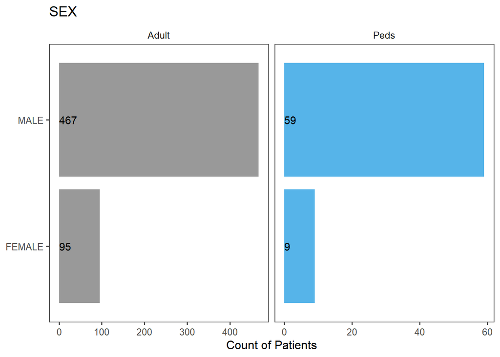

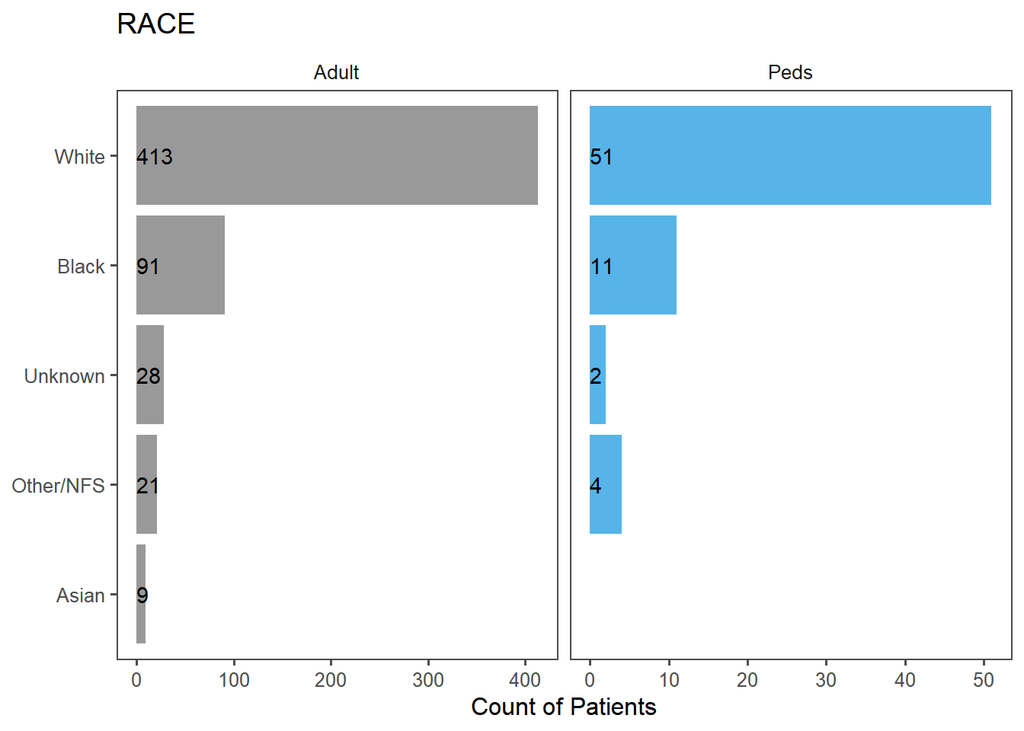

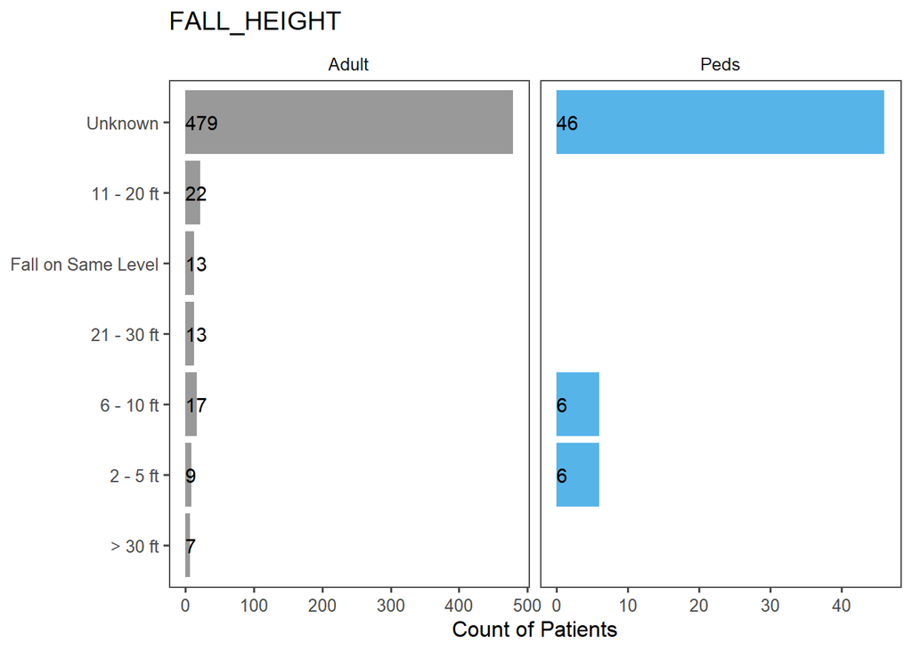

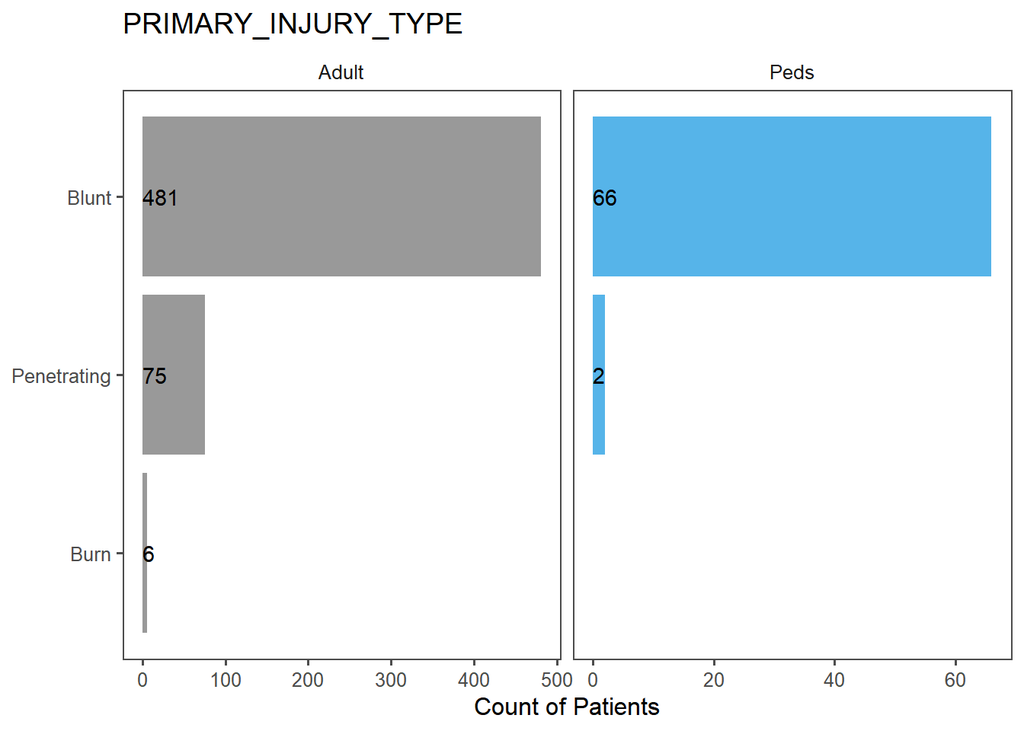

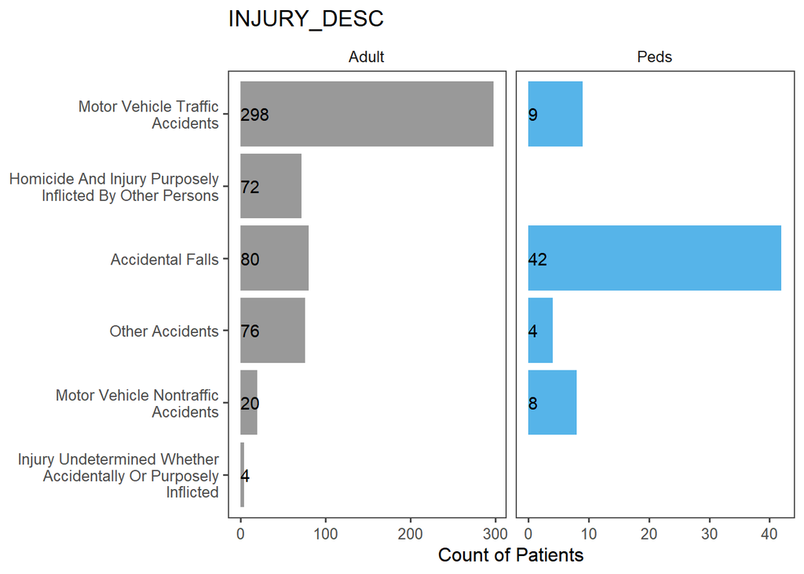

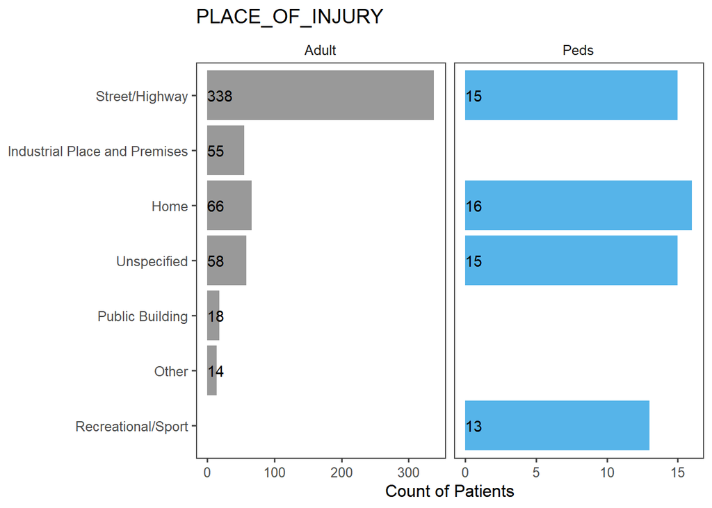

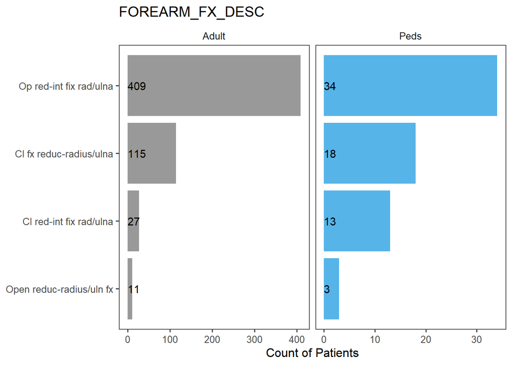

# Predicting Compartment Syndrome Complications

## Class Imbalance

There is a significant class imbalance for pediatric patients that had both forearm surgeries and a fasciotomy. Out of 2,741 patients, only 68 had a fasciotomy resulting in less than 3%. The initial models were memorizing the results and predicting that no patient would have a fasciotomy resulting in a model with a 3% error. From a glance, it appears to be a decent model, but it will not generalize well or help identify patients at high risk for compartment syndrome.

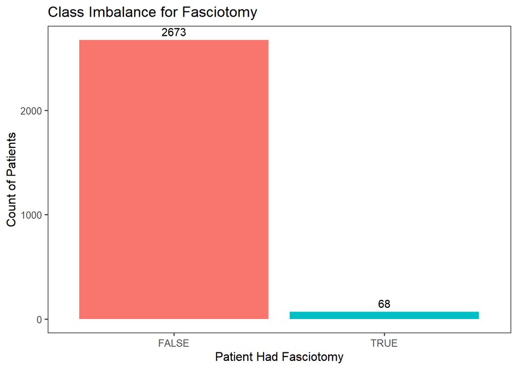

## Balancing the Classes

Using resampling techniques, I decided to create a model with an upsample for a 50/50 split on the data. The results were far more interesting and insightful than the previous model that only memorized that 97% of patients will not have compartment syndrome complications.

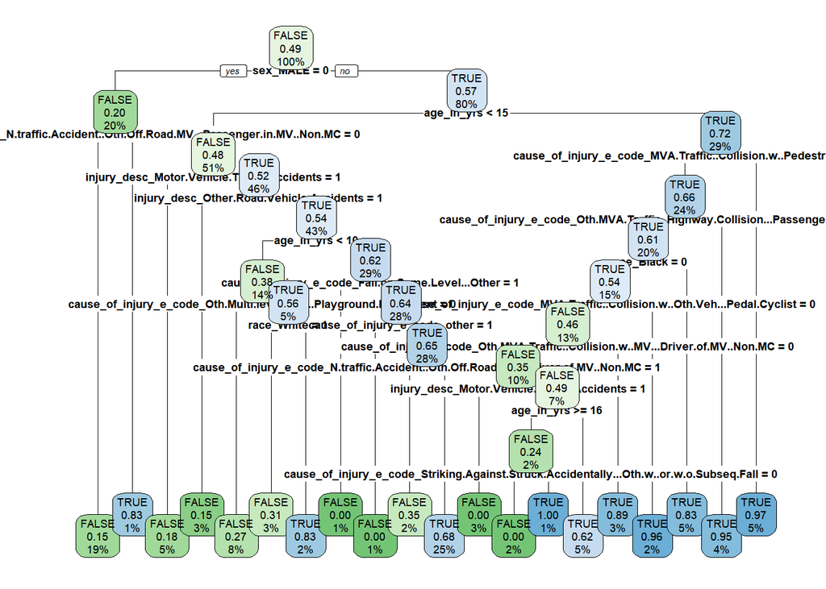

```
##
## Classification tree:
## rpart(formula = fltr_fasciotomy ~ . - id, data = train_data,
##     method = "class")
##
## Variables actually used in tree construction:
##  [1] age_in_yrs
##  [2] cause_of_injury_e_code_Fall.on.Same.Level...Other
##  [3] cause_of_injury_e_code_MVA.Traffic..Collision.w..Oth.Veh...Pedal.Cyclist
##  [4] cause_of_injury_e_code_MVA.Traffic..Collision.w..Pedestrian...Pedestrian
##  [5] cause_of_injury_e_code_N.traffic.Accident..Oth.Off.Road.MV...Driver.of.MV..Non.MC
##  [6] cause_of_injury_e_code_N.traffic.Accident..Oth.Off.Road.MV...Passenger.in.MV..Non.MC
##  [7] cause_of_injury_e_code_Oth.Multi.level.Fall...Playground.Equipment
##  [8] cause_of_injury_e_code_Oth.MVA.Traffic..Collision.w..MV...Driver.of.MV..Non.MC
##  [9] cause_of_injury_e_code_Oth.MVA.Traffic..Highway.Collision...Passenger.in.MV..Non.MC
## [10] cause_of_injury_e_code_other
## [11] cause_of_injury_e_code_Striking.Against.Struck.Accidentally...Oth.w..or.w.o.Subseq.Fall
## [12] injury_desc_Motor.Vehicle.Traffic.Accidents
## [13] injury_desc_Other.Road.Vehicle.Accidents
## [14] race_Black
## [15] race_White
## [16] sex_MALE
##
## Root node error: 4943/10000 = 0.4943
##
## n= 10000
##
##         CP nsplit rel error  xerror      xstd
## 1 0.223346      0   1.00000 1.00000 0.0101147
## 2 0.043294      1   0.77665 0.77665 0.0098388
## 3 0.022254      5   0.60348 0.60125 0.0092459
## 4 0.016589      6   0.58123 0.58082 0.0091525
## 5 0.015982      7   0.56464 0.56787 0.0090905
## 6 0.013049      9   0.53267 0.55007 0.0090014
## 7 0.012219     11   0.50657 0.53854 0.0089413
## 8 0.011734     16   0.44548 0.49423 0.0086925
## 9 0.010000     19   0.41007 0.44467 0.0083777
```

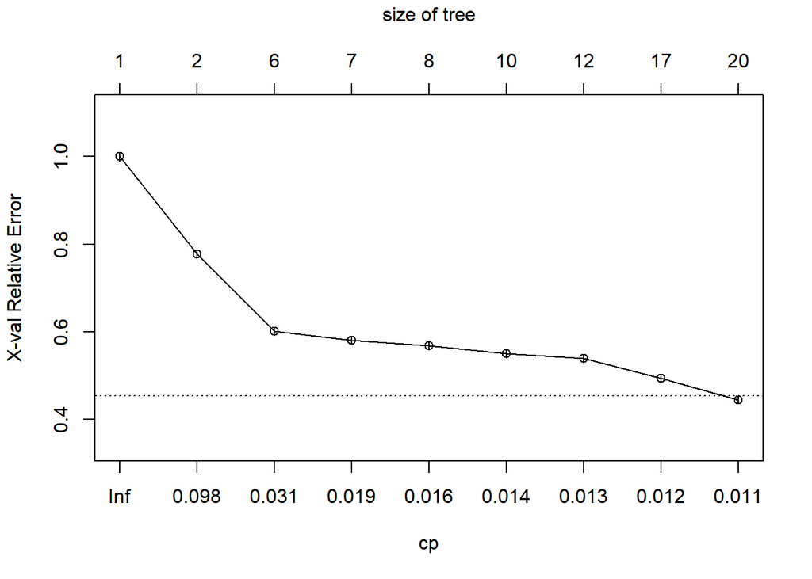

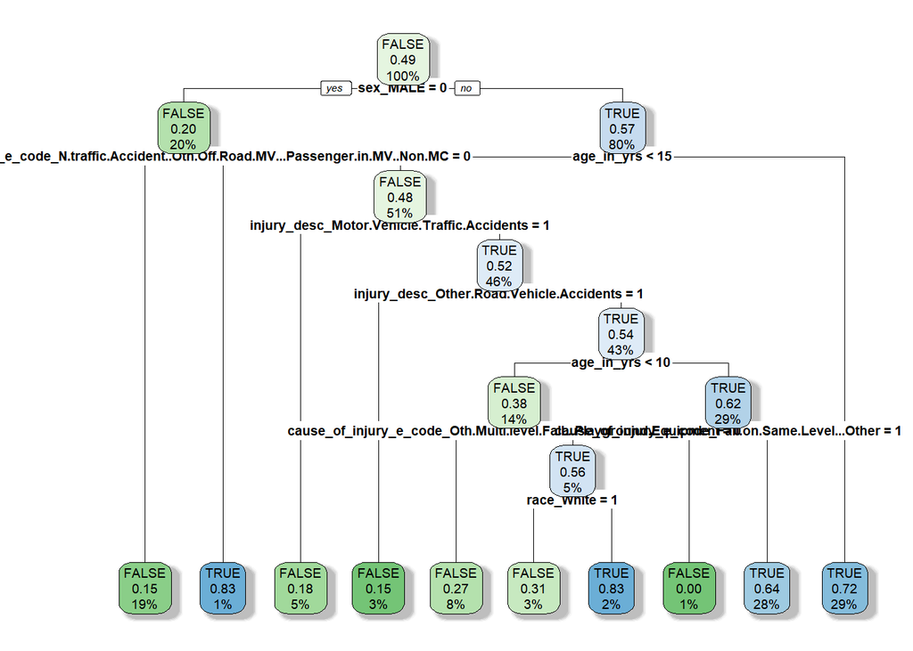

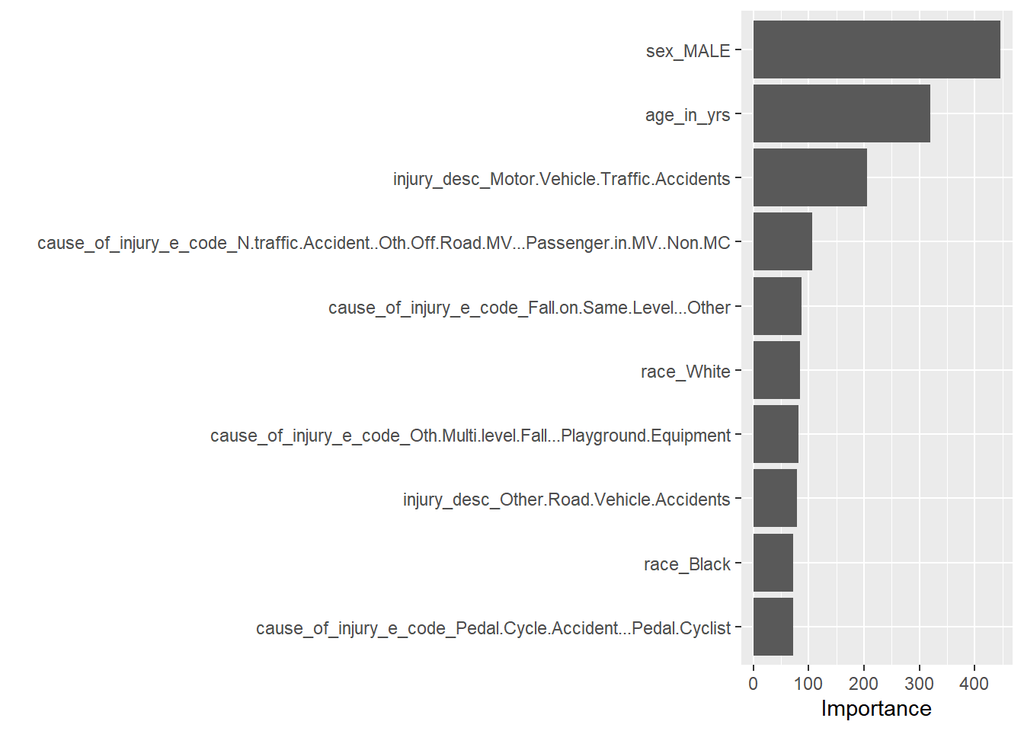

# Over the next 3 Weeks

- Random Forest and XGBoost using SMOTE data
- Association Analysis for series of procedures to understand if there is a sequence of medical events which leads to an increased probability of a patient having complications from compartment syndrome.
- Shiny Interactive Dashboard